# Information Theory and Machine Learning Reveal Synergistic Interactions in Gut Microbiota Related to Food Allergy - data analysis pipeline

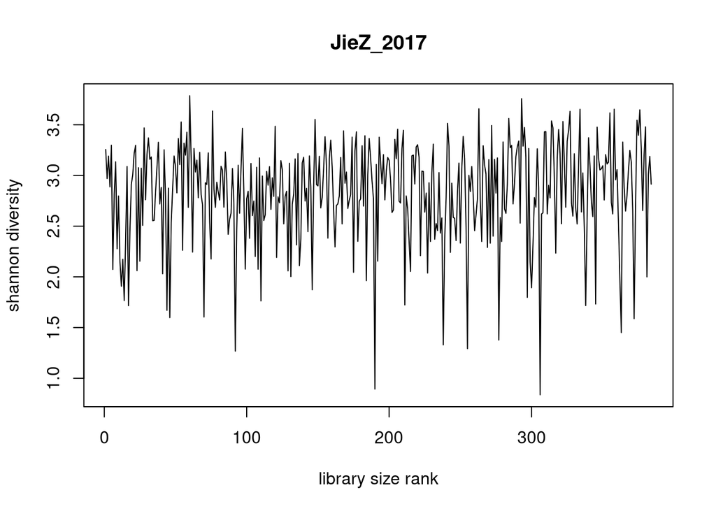

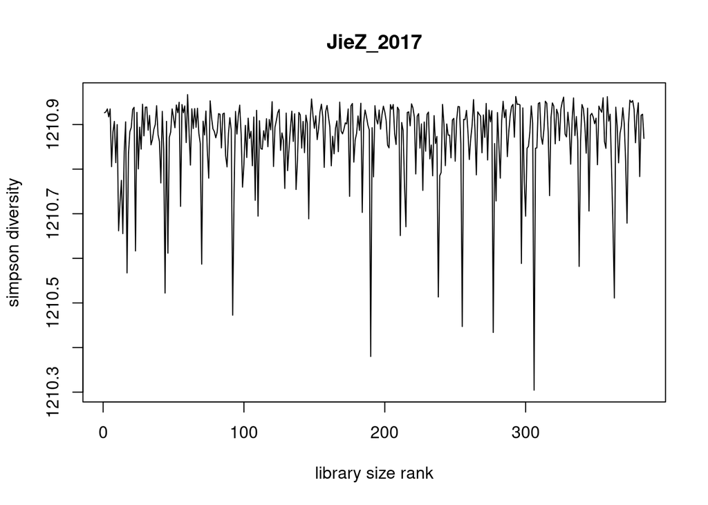

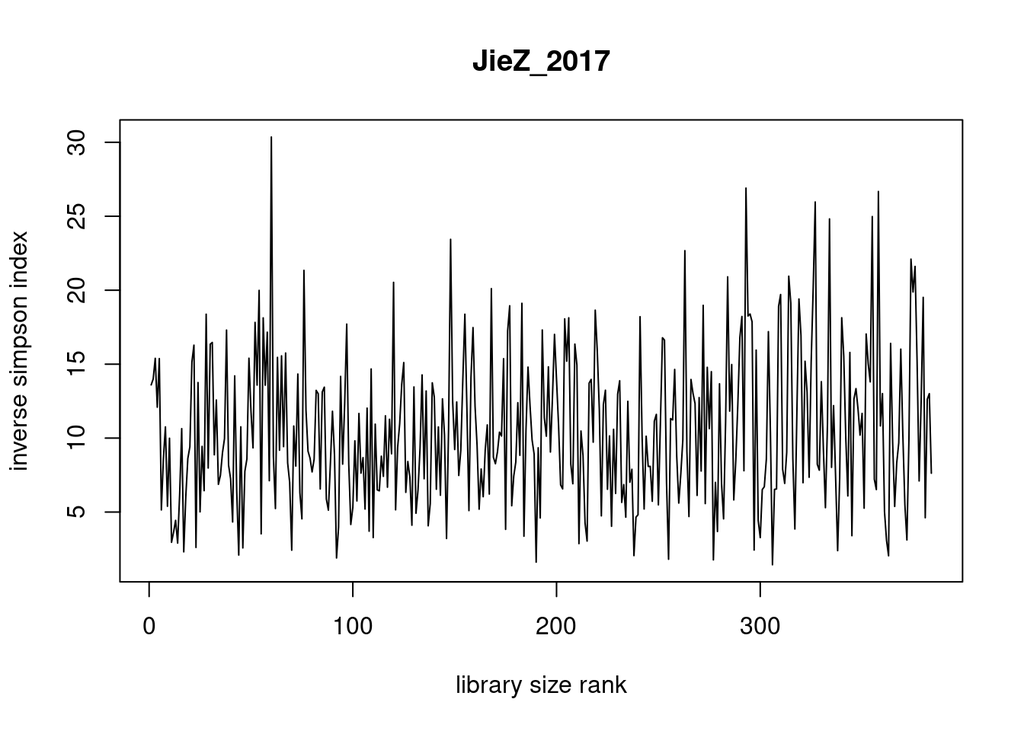

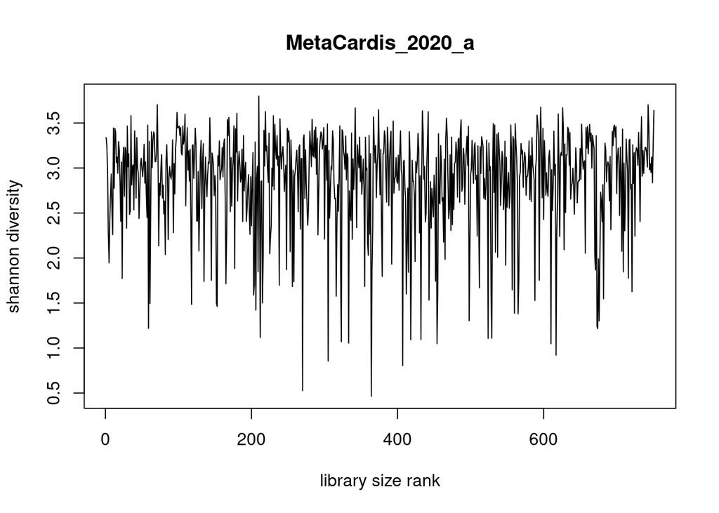

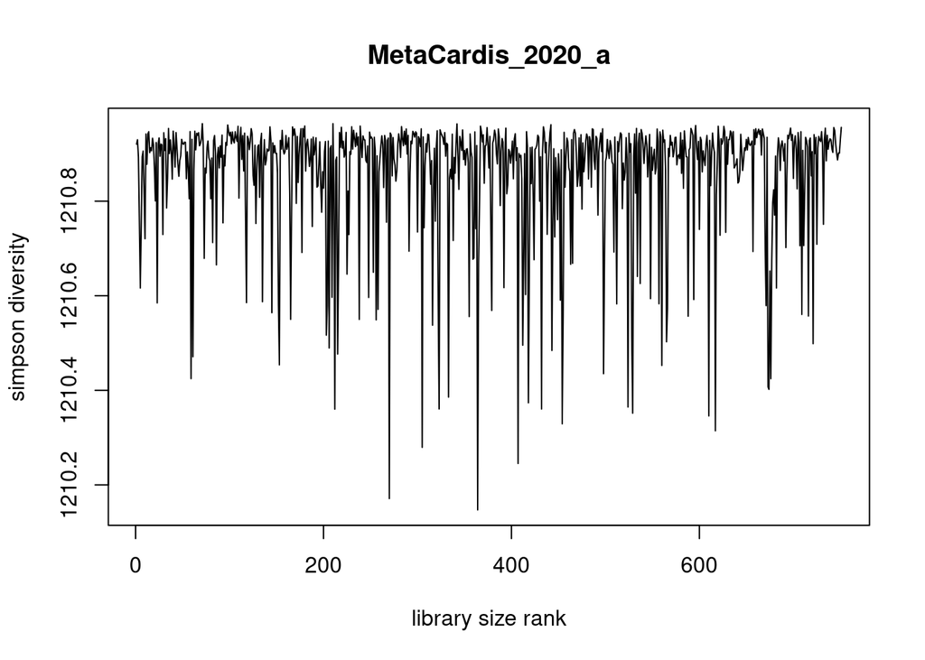

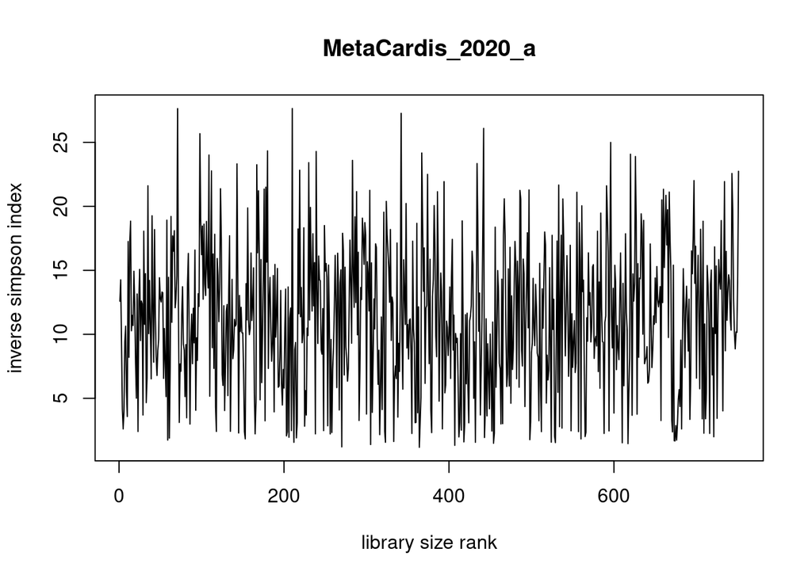

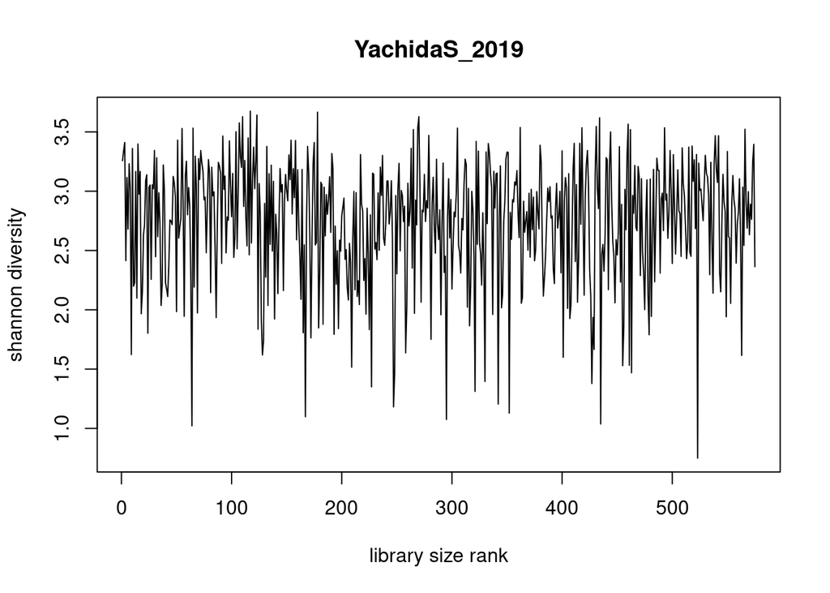

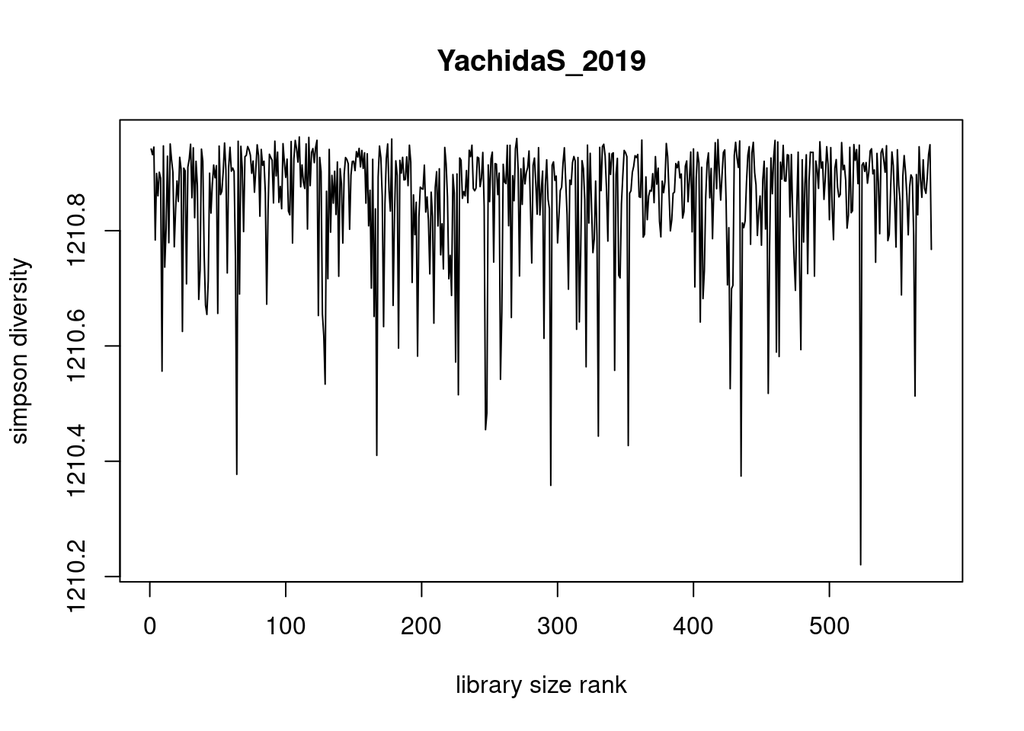

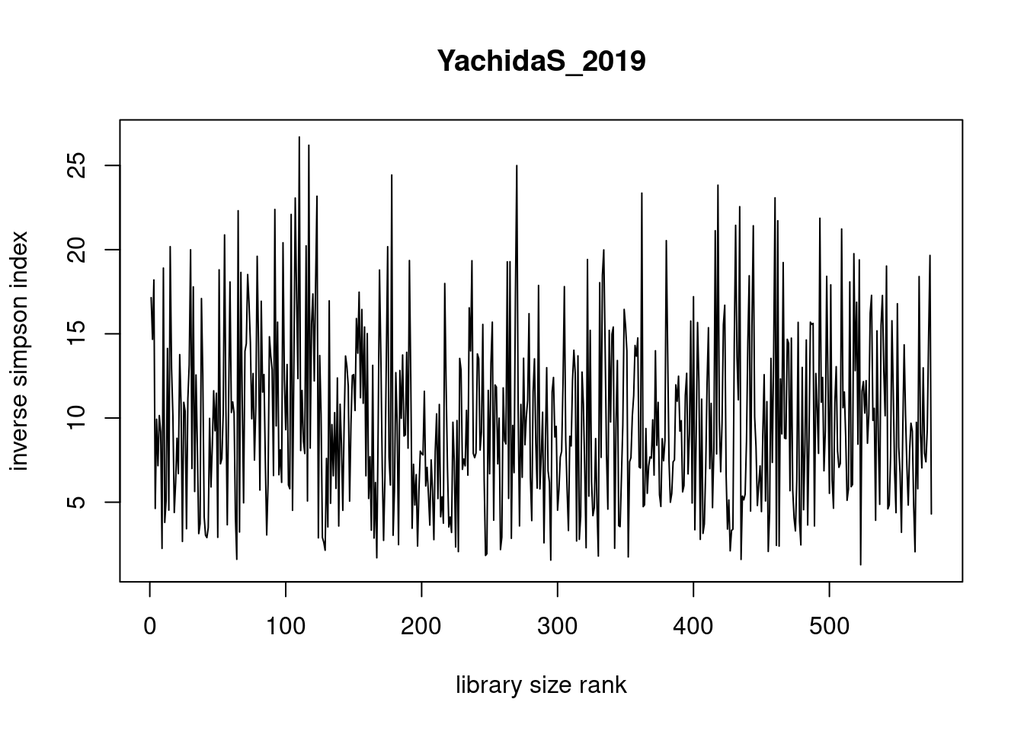

```r
 mapply(diversity_indices, taxa, names(taxa)) |> invisible()
```

At this stage of preprocessing, we do not see any evidence for clear relationship between diversity value and the cumulative abundance, so we do not filter the data further in the “samples” dimension.

Finally, we normalize by total sample abundance:

```r
lapply(taxa, function(data) data/rowSums(data))-> taxa
```

#### Binarization

Below plot shows number of non-zero entries in the abundance table per each column (taxon). These values are seen on Y axis, while each position on X axis corresponds to each taxon. Horizontal line is drawn at 30.

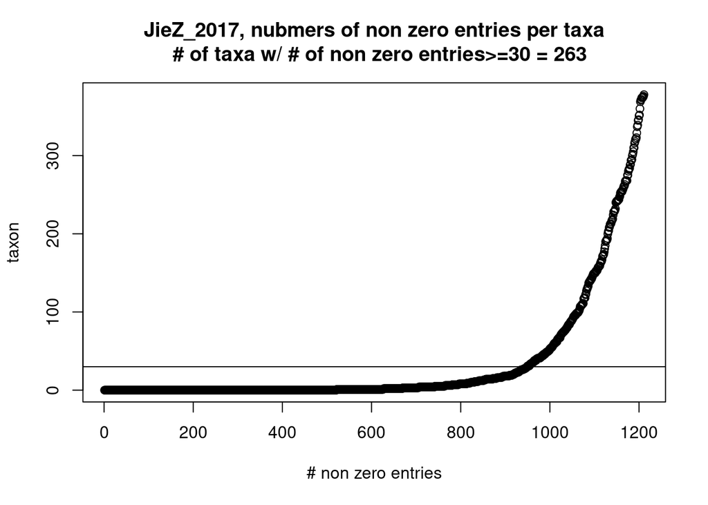

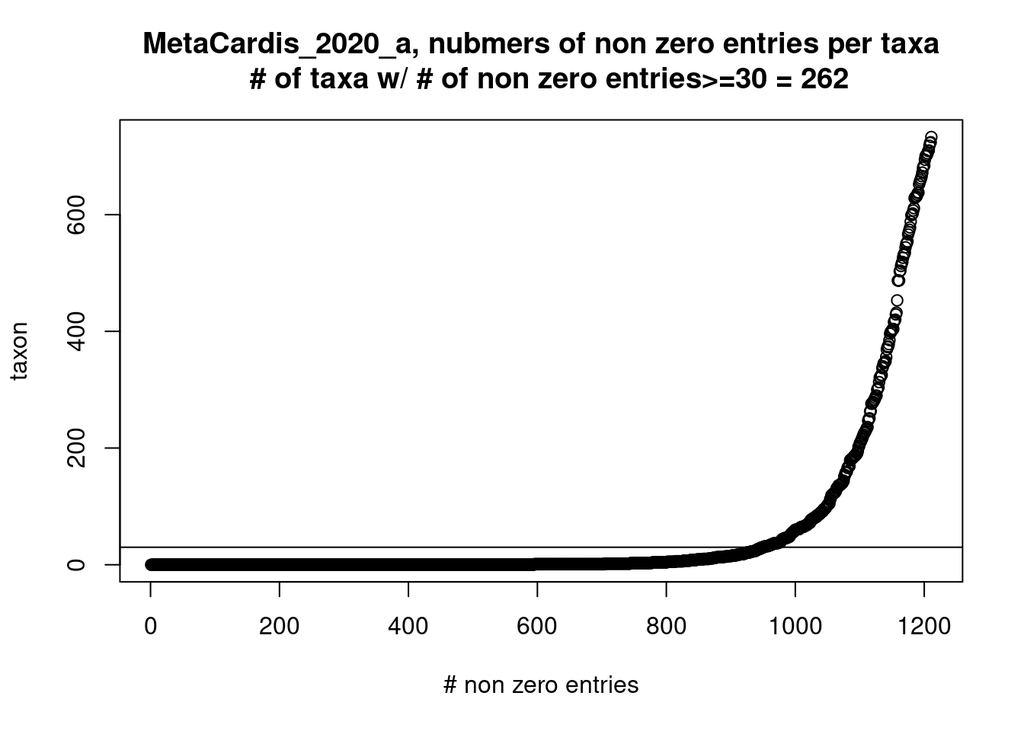

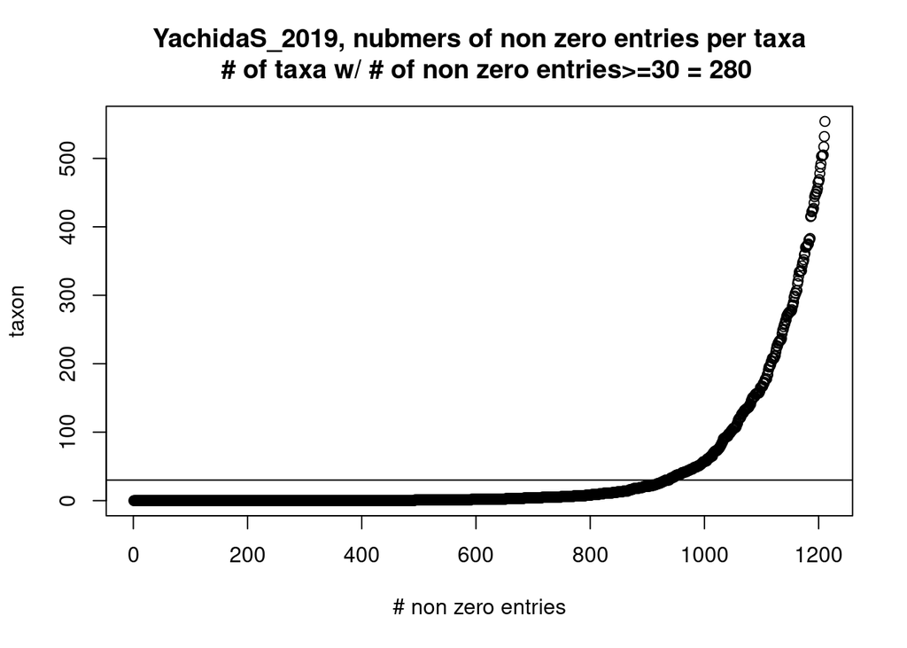

```r
mapply(function(data, name)
  {(colSums(data>0))|> sort() |> plot(main=sprintf("%s, nubmers of non zero entries per taxa
  # of taxa w/ # of non zero entries>=30 = %d",name, sum(colSums(data>0)>=30)  ),
  xlab="# non zero entries",ylab="taxon"); abline(h=30)},
  taxa,names(taxa)) |> invisible()
```

As expected, majority of taxa are very sparse. For our purposes, we limit the analysis to those which have at least 30 non-zero entries.

As for the binarization, we apply it separately per each variable (taxon). We use two approaches: binarization based on median or zero. In case of median, entries of normalized abundance $\leq$ median for each taxon are zeroed out, while for “zero” strategy, zero entries get mapped to zeros an other to ones. The only difference will be visible in case of common taxa, being present in more than half of the samples.

### test FS procedures through subsampling validation

This resampling strategy is known in literature as `jackknife`.

`FS_functions.R` contains functions for performing MDFS based feature selection and U-test wrapper. Functions take `X` as an input feature table and `y` as the trait of interest and return indices of relevant variables (columns in `X`), corresponding feature scores and their p-values.

`MDFS_FS` performs MDFS in 1D and 2D mode, using 2 binarisation methods (median or zero based) and returns, along with the mentioned components, data on the identified interactions.

Output of `MDFS_FS` is composed of 4 sublists (1 per each mentioned variant). 2 sublists (those from 2D mode) contain fields `partner_df`, `partner_set` and `interaction_data` which contain information on the pairwise interactions relevant to `y`.

- `partner_df` is a data.frame with one row per each pair of 2D relevant variable with some other variable, that increased its information on gain on `y` by meaningful amount. We set this threshold to the minimum IG obtained for relevant variables in 1D.
- `partner_set` contains names of the taxa that were found as partners, but were not relevant in 2D by themselves.
- `interaction_data` extends the information on the interaction in `partner_set` and can be used to obtain synthetic variables, one per each interaction, that can be used in inference problems, along with regular features. Function `generate_interaction_variables()`, enumerates 4 states in each interaction, according to the increasing probablity of `y==1`. Thus, based on `interaction_data`, it can create an array of additional, discrete, ordinal features.

#### Base result - on the whole datasets

```r
source("FS_functions.R")

MDFS_global<- lapply(names(taxa), function(coh)

          MDFS_FS(X= taxa[[coh]], y = decision[[coh]], lvl = 0.05, p.adjust.method = "holm", seed = 123,mc = 30)
  )

U_global<- lapply(names(taxa), function(coh)

  U_test_FS(X = taxa[[coh]], y = decision[[coh]], lvl=0.05, p.adjust.method = "holm", min_presence=30)
  )
```

#### Subsampling sets preparation

```r
source("subsample_nonrepeating_donors.R")
n_repeats=500
lop=0.37
if (!file.exists("new_cohorts_subsample.rds")){
subsample<- list()
for (cohort in cohort_ids) {
    IDs1<-names(decision[[cohort]][ decision[[cohort]]==1 ])
    IDs0<-setdiff(names(decision[[cohort]]), IDs1)
    subsample[[cohort]]=list()
        for (r in 1:n_repeats){
        set.seed(r)
        keep1<- sample(IDs1, floor((1-lop)*length(IDs1)),replace=FALSE)
        keep0<- sample(IDs0, floor((1-lop)*length(IDs0)),replace=FALSE)
        subsample[[cohort]][[r]]= list()
        subsample[[cohort]][[r]]$keep= c( keep1, keep0)
        subsample[[cohort]][[r]]$leave= setdiff(names(decision[[cohort]]),
                            c(keep1,keep0))
        }
    }
    saveRDS(subsample,"new_cohorts_subsample.rds")
}else{
subsample<- readRDS("new_cohorts_subsample.rds")
}
```

#### Testing

```r
source("FS_functions.R")
lop=0.37
set.seed(123)
n_repeats=500
lapply(cohort_ids, function(._) sample.int(452332,n_repeats))-> seeds
names(seeds)<-cohort_ids


features<- list(md1D=list(),
                md12D=list(),
                md12Dp=list(),
                u=list()
                )
for (fs in names(features))
    for (coh in cohort_ids)
    features[[fs]][[coh]]=list()

        #cohort name    #repeat   #leave out perc.
fs_j_pattern="features/%s_fs_set_j=%d_lop=%.2f.rds"

full_MDFSres<- full_Ures<-list()
for (coh in cohort_ids) full_MDFSres[[coh]]<-full_Ures[[coh]]<-list()

for (j in 1:n_repeats){
for (coh in cohort_ids){

  fs_j_fname= sprintf(fs_j_pattern,coh,j,lop)
  if(!file.exists(fs_j_fname)){
      message(fs_j_fname)
      set.seed(seeds[[coh]][[j]])
    MDFS_FS(X= taxa[[coh]][ subsample[[coh]][[j]]$keep, ],
          y= decision[[coh]][ subsample[[coh]][[j]]$keep ], lvl=0.05, p.adjust.method = "holm",
          seed= seeds[[coh]][[j]],
          mc=30 #minimum allowed class size of binarized taxa abundance
          )-> all_mdfs_j
    U_test_FS(X= taxa[[coh]][ subsample[[coh]][[j]]$keep, ],
          y= decision[[coh]][ subsample[[coh]][[j]]$keep ],
        lvl = 0.05,
        p.adjust.method = "holm", min_presence=30)->u_j
    fs_j=list(mdfs=all_mdfs_j, u=u_j)
    saveRDS(fs_j, fs_j_fname)
                } else
                {
    fs_j= readRDS(fs_j_fname)
        all_mdfs_j=fs_j$mdfs
        u_j=fs_j$u
                }
    full_MDFSres[[coh]][[j]]=all_mdfs_j
    full_Ures[[coh]][[j]]=u_j

    features$u[[coh]][[j]]=u_j$rel_set
    features$md1D[[coh]][[j]]=union(all_mdfs_j$res_1Dm$rel_set, all_mdfs_j$res_1D0$rel_set)
        features$md12D[[coh]][[j]]=Reduce(union, list(all_mdfs_j$res_2Dm$rel_set,
                                                  all_mdfs_j$res_2D0$rel_set,
                                                  features$md1D[[coh]][[j]]))
        features$md12Dp[[coh]][[j]]=Reduce(union, list(all_mdfs_j$res_2Dm$partner_set,
                                                       all_mdfs_j$res_2D0$partner_set,
                                                  features$md12D[[coh]][[j]]))

    model_file_string="RF_models/%s_j=%d_fs=%s_lop=%.2f.rds"
    for (fs_method in c(names(features),"md12DpInt" )){
            fname=sprintf(model_file_string,coh,j,fs_method,lop)
        if (!file.exists(fname)){
        message(fname)
        set.seed(seeds[[coh]][[j]])
        RF_fs_j=NA
        f_key <- if(fs_method=="md12pInt") "md12Dp" else fs_method
        if (length(features[[f_key]][[coh]][[j]])) {
            X_keep<- taxa[[coh]][ subsample[[coh]][[j]]$keep, ,
                         drop=FALSE ]
            X_keep_sel<- X_keep[, features[[f_key]][[coh]][[j]], drop=FALSE ]
            X_rf<- X_keep_sel
            if (fs_method=="md12DpInt")
                {
                if (length(full_MDFSres[[coh]][[j]]$res_2Dm$interaction_data)>1) {
                    interaction_xm<- generate_interaction_variables(
                                        X_keep,
                            full_MDFSres[[coh]][[j]]$res_2Dm$interaction_data)
                    X_rf<- cbind(X_rf, interaction_xm)
                    }
                if (length(full_MDFSres[[coh]][[j]]$res_2D0$interaction_data)>1) {
                    interaction_x0<- generate_interaction_variables(
                                        X_keep,
                            full_MDFSres[[coh]][[j]]$res_2D0$interaction_data)
                    X_rf<- cbind(X_rf, interaction_x0)
                    }

                }

            y_rf<- decision[[coh]][ subsample[[coh]][[j]]$keep ] |> as.factor()
            RF_fs_j= randomForest(x= X_rf,
                          y=y_rf)
            }
          saveRDS(RF_fs_j, file=fname)
        }

    }

}
message(sprintf( "%d / %d done", j, n_repeats))
}
```

```
1 / 500 done
```

```
2 / 500 done
```

```
3 / 500 done
```

```
4 / 500 done
```

```
5 / 500 done
```

```
6 / 500 done
```

```
7 / 500 done
```

```
8 / 500 done
```

```
9 / 500 done
```

```
10 / 500 done
```

```
11 / 500 done
```

```
12 / 500 done
```

```
13 / 500 done
```

```
14 / 500 done
```

```
15 / 500 done
```

```
16 / 500 done
```

```
17 / 500 done
```

```
18 / 500 done
```

```
19 / 500 done
```

```
20 / 500 done
```

```
21 / 500 done
```

```
22 / 500 done
```

```
23 / 500 done
```

```
24 / 500 done
```

```
25 / 500 done
```

```
26 / 500 done
```

```
27 / 500 done
```

```
28 / 500 done
```

```
29 / 500 done
```

```
30 / 500 done
```

```
31 / 500 done
```

```
32 / 500 done
```

```
33 / 500 done
```

```
34 / 500 done
```

```
35 / 500 done
```

```
36 / 500 done
```

```
37 / 500 done
```

```
38 / 500 done
```

```
39 / 500 done
```

```
40 / 500 done
```

```
41 / 500 done
```

```
42 / 500 done
```

```
43 / 500 done
```

```
44 / 500 done
```

```
45 / 500 done
```

```
46 / 500 done
```

```
47 / 500 done
```

```
48 / 500 done
```

```
49 / 500 done
```

```
50 / 500 done
```

```
51 / 500 done
```

```
52 / 500 done
```

```
53 / 500 done
```

```
54 / 500 done
```

```
55 / 500 done
```

```
56 / 500 done
```

```
57 / 500 done
```

```
58 / 500 done
```

```
59 / 500 done
```

```
60 / 500 done
```

```
61 / 500 done
```

```
62 / 500 done
```

```
63 / 500 done
```

```
64 / 500 done
```

```
65 / 500 done
```

```
66 / 500 done
```

```
67 / 500 done
```

```
68 / 500 done
```

```
69 / 500 done
```

```
70 / 500 done
```

```
71 / 500 done
```

```
72 / 500 done
```

```
73 / 500 done
```

```
74 / 500 done
```

```
75 / 500 done
```

```
76 / 500 done
```

```
77 / 500 done
```

```
78 / 500 done
```

```
79 / 500 done
```

```
80 / 500 done
```

```
81 / 500 done
```

```
82 / 500 done
```

```
83 / 500 done
```

```
84 / 500 done
```

```
85 / 500 done
```

```
86 / 500 done
```

```
87 / 500 done
```

```
88 / 500 done
```

```
89 / 500 done
```

```
90 / 500 done
```

```
91 / 500 done
```

```
92 / 500 done
```

```
93 / 500 done
```

```
94 / 500 done
```

```
95 / 500 done
```

```
96 / 500 done
```

```
97 / 500 done
```

```
98 / 500 done
```

```
99 / 500 done
```

```
100 / 500 done
```

```
101 / 500 done
```

```
102 / 500 done
```

```
103 / 500 done
```

```
104 / 500 done
```

```
105 / 500 done
```

```
106 / 500 done
```

```
107 / 500 done
```

```
108 / 500 done
```

```
109 / 500 done
```

```
110 / 500 done
```

```
111 / 500 done
```

```
112 / 500 done
```

```
113 / 500 done
```

```
114 / 500 done
```

```
115 / 500 done
```

```
116 / 500 done
```

```
117 / 500 done
```

```
118 / 500 done
```

```
119 / 500 done
```

```
120 / 500 done
```

```
121 / 500 done
```

```
122 / 500 done
```

```
123 / 500 done
```

```
124 / 500 done
```

```
125 / 500 done
```

```
126 / 500 done
```

```
127 / 500 done
```

```
128 / 500 done
```

```
129 / 500 done
```

```
130 / 500 done
```

```
131 / 500 done
```

```
132 / 500 done
```

```
133 / 500 done
```

```
134 / 500 done
```

```
135 / 500 done
```

```
136 / 500 done
```

```
137 / 500 done
```

```
138 / 500 done
```

```
139 / 500 done
```

```
140 / 500 done
```

```
141 / 500 done
```

```
142 / 500 done
```

```
143 / 500 done
```

```
144 / 500 done
```

```
145 / 500 done
```

```
146 / 500 done
```

```
147 / 500 done
```

```
148 / 500 done
```

```
149 / 500 done
```

```
150 / 500 done
```

```
151 / 500 done
```

```
152 / 500 done
```

```
153 / 500 done
```

```
154 / 500 done
```

```
155 / 500 done
```

```
156 / 500 done
```

```
157 / 500 done
```

```
158 / 500 done
```

```
159 / 500 done
```

```
160 / 500 done
```

```
161 / 500 done
```

```
162 / 500 done
```

```
163 / 500 done
```

```
164 / 500 done
```

```
165 / 500 done
```

```
166 / 500 done
```

```
167 / 500 done
```

```
168 / 500 done
```

```
169 / 500 done
```

```
170 / 500 done
```

```
171 / 500 done
```

```
172 / 500 done
```

```
173 / 500 done
```

```
174 / 500 done
```

```
175 / 500 done
```

```
176 / 500 done
```

```
177 / 500 done
```

```
178 / 500 done
```

```
179 / 500 done
```

```
180 / 500 done
```

```
181 / 500 done
```

```
182 / 500 done
```

```
183 / 500 done
```

```
184 / 500 done
```

```
185 / 500 done
```

```
186 / 500 done
```

```
187 / 500 done
```

```
188 / 500 done
```

```
189 / 500 done
```

```
190 / 500 done
```

```
191 / 500 done
```

```
192 / 500 done
```

```
193 / 500 done
```

```
194 / 500 done
```

```
195 / 500 done
```

```
196 / 500 done
```

```
197 / 500 done
```

```
198 / 500 done
```

```
199 / 500 done
```

```
200 / 500 done
```

```
201 / 500 done
```

```
202 / 500 done
```

```
203 / 500 done
```

```
204 / 500 done
```

```
205 / 500 done
```

```
206 / 500 done
```

```
207 / 500 done
```

```
208 / 500 done
```

```
209 / 500 done
```

```
210 / 500 done
```

```
211 / 500 done
```

```
212 / 500 done
```

```
213 / 500 done
```

```
214 / 500 done
```

```
215 / 500 done
```

```
216 / 500 done
```

```
217 / 500 done
```

```
218 / 500 done
```

```
219 / 500 done
```

```
220 / 500 done
```

```
221 / 500 done
```

```
222 / 500 done
```

```
223 / 500 done
```

```
224 / 500 done
```

```
225 / 500 done
```

```
226 / 500 done
```

```
227 / 500 done
```

```
228 / 500 done
```

```
229 / 500 done
```

```
230 / 500 done
```

```
231 / 500 done
```

```
232 / 500 done
```

```
233 / 500 done
```

```
234 / 500 done
```

```
235 / 500 done
```

```
236 / 500 done
```

```
237 / 500 done
```

```
238 / 500 done
```

```
239 / 500 done
```

```
240 / 500 done
```

```
241 / 500 done
```

```
242 / 500 done
```

```
243 / 500 done
```

```
244 / 500 done
```

```
245 / 500 done
```

```
246 / 500 done
```

```
247 / 500 done
```

```
248 / 500 done
```

```
249 / 500 done
```

```
250 / 500 done
```

```
251 / 500 done
```

```
252 / 500 done
```

```
253 / 500 done
```

```
254 / 500 done
```

```
255 / 500 done
```

```
256 / 500 done
```

```
257 / 500 done
```

```
258 / 500 done
```

```
259 / 500 done
```

```
260 / 500 done
```

```
261 / 500 done
```

```
262 / 500 done
```

```
263 / 500 done
```

```
264 / 500 done
```

```
265 / 500 done
```

```
266 / 500 done
```

```
267 / 500 done
```

```
268 / 500 done
```

```
269 / 500 done
```

```
270 / 500 done
```

```
271 / 500 done
```

```
272 / 500 done
```

```
273 / 500 done
```

```
274 / 500 done
```

```
275 / 500 done
```

```
276 / 500 done
```

```
277 / 500 done
```

```
278 / 500 done
```

```
279 / 500 done
```

```
280 / 500 done
```

```
281 / 500 done
```

```
282 / 500 done
```

```
283 / 500 done
```

```
284 / 500 done
```

```
285 / 500 done
```

```
286 / 500 done
```

```
287 / 500 done
```

```
288 / 500 done
```

```
289 / 500 done
```

```
290 / 500 done
```

```
291 / 500 done
```

```
292 / 500 done
```

```
293 / 500 done
```

```
294 / 500 done
```

```
295 / 500 done
```

```
296 / 500 done
```

```
297 / 500 done
```

```
298 / 500 done
```

```
299 / 500 done
```

```
300 / 500 done
```

```
301 / 500 done
```

```
302 / 500 done
```

```
303 / 500 done
```

```
304 / 500 done
```

```
305 / 500 done
```

```
306 / 500 done
```

```
307 / 500 done
```

```
308 / 500 done
```

```
309 / 500 done
```

```
310 / 500 done
```

```
311 / 500 done
```

```
312 / 500 done
```

```
313 / 500 done
```

```
314 / 500 done
```

```
315 / 500 done
```

```
316 / 500 done
```

```
317 / 500 done
```

```
318 / 500 done
```

```
319 / 500 done
```

```
320 / 500 done
```

```
321 / 500 done
```

```
322 / 500 done
```

```
323 / 500 done
```

```
324 / 500 done
```

```
325 / 500 done
```

```
326 / 500 done
```

```
327 / 500 done
```

```
328 / 500 done
```

```
329 / 500 done
```

```
330 / 500 done
```

```
331 / 500 done
```

```
332 / 500 done
```

```
333 / 500 done
```

```
334 / 500 done
```

```
335 / 500 done
```

```
336 / 500 done
```

```
337 / 500 done
```

```
338 / 500 done
```

```
339 / 500 done
```

```
340 / 500 done
```

```
341 / 500 done
```

```
342 / 500 done
```

```
343 / 500 done
```

```
344 / 500 done
```

```
345 / 500 done
```

```
346 / 500 done
```

```
347 / 500 done
```

```
348 / 500 done
```

```
349 / 500 done
```

```
350 / 500 done
```

```
351 / 500 done
```

```
352 / 500 done
```

```
353 / 500 done
```

```
354 / 500 done
```

```
355 / 500 done
```

```
356 / 500 done
```

```
357 / 500 done
```

```
358 / 500 done
```

```
359 / 500 done
```

```
360 / 500 done
```

```
361 / 500 done
```

```
362 / 500 done
```

```
363 / 500 done
```

```
364 / 500 done
```

```
365 / 500 done
```

```
366 / 500 done
```

```
367 / 500 done
```

```
368 / 500 done
```

```
369 / 500 done
```

```
370 / 500 done
```

```
371 / 500 done
```

```
372 / 500 done
```

```
373 / 500 done
```

```
374 / 500 done
```

```
375 / 500 done
```

```
376 / 500 done
```

```
377 / 500 done
```

```
378 / 500 done
```

```
379 / 500 done
```

```
380 / 500 done
```

```
381 / 500 done
```

```
382 / 500 done
```

```
383 / 500 done
```

```
384 / 500 done
```

```
385 / 500 done
```

```
386 / 500 done
```

```
387 / 500 done
```

```
388 / 500 done
```

```
389 / 500 done
```

```
390 / 500 done
```

```
391 / 500 done
```

```
392 / 500 done
```

```
393 / 500 done
```

```
394 / 500 done
```

```
395 / 500 done
```

```
396 / 500 done
```

```
397 / 500 done
```

```
398 / 500 done
```

```
399 / 500 done
```

```
400 / 500 done
```

```
401 / 500 done
```

```
402 / 500 done
```

```
403 / 500 done
```

```
404 / 500 done
```

```
405 / 500 done
```

```
406 / 500 done
```

```
407 / 500 done
```

```
408 / 500 done
```

```
409 / 500 done
```

```
410 / 500 done
```

```
411 / 500 done
```

```
412 / 500 done
```

```
413 / 500 done
```

```
414 / 500 done
```

```
415 / 500 done
```

```
416 / 500 done
```

```
417 / 500 done
```

```
418 / 500 done
```

```
419 / 500 done
```

```
420 / 500 done
```

```
421 / 500 done
```

```
422 / 500 done
```

```
423 / 500 done
```

```
424 / 500 done
```

```
425 / 500 done
```

```
426 / 500 done
```

```
427 / 500 done
```

```
428 / 500 done
```

```
429 / 500 done
```

```
430 / 500 done
```

```
431 / 500 done
```

```
432 / 500 done
```

```
433 / 500 done
```

```
434 / 500 done
```

```
435 / 500 done
```

```
436 / 500 done
```

```
437 / 500 done
```

```
438 / 500 done
```

```
439 / 500 done
```

```
440 / 500 done
```

```
441 / 500 done
```

```
442 / 500 done
```

```
443 / 500 done
```

```
444 / 500 done
```

```
445 / 500 done
```

```
446 / 500 done
```

```
447 / 500 done
```

```
448 / 500 done
```

```
449 / 500 done
```

```
450 / 500 done
```

```
451 / 500 done
```

```
452 / 500 done
```

```
453 / 500 done
```

```
454 / 500 done
```

```
455 / 500 done
```

```
456 / 500 done
```

```
457 / 500 done
```

```
458 / 500 done
```

```
459 / 500 done
```

```
460 / 500 done
```

```
461 / 500 done
```

```
462 / 500 done
```

```
463 / 500 done
```

```
464 / 500 done
```

```
465 / 500 done
```

```
466 / 500 done
```

```
467 / 500 done
```

```
468 / 500 done
```

```
469 / 500 done
```

```
470 / 500 done
```

```
471 / 500 done
```

```
472 / 500 done
```

```
473 / 500 done
```

```
474 / 500 done
```

```
475 / 500 done
```

```
476 / 500 done
```

```
477 / 500 done
```

```
478 / 500 done
```

```
479 / 500 done
```

```
480 / 500 done
```

```
481 / 500 done
```

```
482 / 500 done
```

```
483 / 500 done
```

```
484 / 500 done
```

```
485 / 500 done
```

```
486 / 500 done
```

```
487 / 500 done
```

```
488 / 500 done
```

```
489 / 500 done
```

```
490 / 500 done
```

```
491 / 500 done
```

```
492 / 500 done
```

```
493 / 500 done
```

```
494 / 500 done
```

```
495 / 500 done
```

```
496 / 500 done
```

```
497 / 500 done
```

```
498 / 500 done
```

```
499 / 500 done
```

```
500 / 500 done
```

```r
n_repeats=500
#n_repeats=30
source("balanced_decision.R")
METHODS=c(names(features),"md12DpInt")
METRICS=c("AUC","OR")
odds_ratio<- function(y_pred, y){
 # if(length(unique(y_pred))<2){
    #print(sprintf("bad table %s %s",method, cohort));
  #  return(1)}
  stopifnot(length(unique(y))==2)
  CM= matrix(nrow=2,ncol=2)
  CM[1,1]=sum( (y_pred==0) & (y==0))
  CM[2,1]=sum( (y_pred==1) & (y==0))
  CM[1,2]=sum( (y_pred==0) & (y==1))
  CM[2,2]=sum( (y_pred==1) & (y==1))
  if (any(CM==0)) CM= CM + 1
  (CM[2,2]*CM[1,1])/(CM[1,2]*CM[2,1])
}

if (!file.exists("performance_additional.rds")) {
performance=array(dim = c(length(cohort_ids),
                          length(METHODS),length(METRICS),
                          n_repeats),
                  dimnames = list(cohort_ids,
                                  METHODS,
                                  METRICS,
                                  NULL  #500 repeats
                                  )
                  )

pred_thr= array(NA, dim= c(length(cohort_ids),
                           length(METHODS),n_repeats),
                 dimnames = list(cohort_ids,
                                  METHODS,
                                  NULL  #500 repeats
                                  )
)

for (j in 1:n_repeats){
  for (coh in cohort_ids){
  for (method in METHODS){
    fname=sprintf(model_file_string,coh,j,method,lop)
  RF_mj<- readRDS(fname)
  no_features<- (length(RF_mj)==1)
    if (no_features){
    #  print(sprintf("null %s %s",coh,method))
      performance[coh,method,"AUC",j]=0.5
      performance[coh,method,"OR",j]=1
    } else {
    f_key= if (method %in% names(features)) method else "md12Dp"
    X_test<- taxa[[coh]][ subsample[[coh]][[j]]$leave, ,drop=FALSE]
    X_rf<- X_test[, features[[f_key]][[coh]][[j]], drop=FALSE ]
    if (method=="md12DpInt"){
      if (length(full_MDFSres[[coh]][[j]]$res_2Dm$interaction_data)>1){
                    interaction_xm<- generate_interaction_variables(X_test, full_MDFSres[[coh]][[j]]$res_2Dm$interaction_data)
                    X_rf<- cbind(X_rf, interaction_xm)
              }
      if (length(full_MDFSres[[coh]][[j]]$res_2D0$interaction_data)>1){
                    interaction_x0<- generate_interaction_variables(X_test, full_MDFSres[[coh]][[j]]$res_2D0$interaction_data)
                    X_rf<- cbind(X_rf, interaction_x0)
      }
    X_rf_ref<-X_rf
    }
    test_pred= predict(RF_mj, newdata=  X_rf,
                      type="prob"  )[,2]
    y_thr= balanced.decision(x = RF_mj$votes[,2],
                             y= decision[[coh]][   subsample[[coh]][[j]]$keep ] )$threshold
    pred_thr[coh,method,j]=y_thr
    y_pbin<- (test_pred >= y_thr)
    confusion=table(Predicted=y_pbin,Actual= decision[[coh]][   subsample[[coh]][[j]]$leave ] )
    performance[coh,method,"AUC",j]= auc(response=decision[[coh]][   subsample[[coh]][[j]]$leave ],
                                        predictor=test_pred,quiet=TRUE)|> as.numeric()
    performance[coh,method,"OR",j]=  odds_ratio(y_pbin, decision[[coh]][   subsample[[coh]][[j]]$leave ])

    }
  }

  }
  j_= j-1
  if (j_==0) message(paste0(rep("_",n_repeats %/% 10),collapse=""))
  if ((j_>0) && (j_ %% 10 == 0)) cat("#")
}

} else {
  performance<-readRDS("performance_additional.rds")
}
```

```r
if (!file.exists("performance_additional.rds")) {
saveRDS(performance, "performance_additional.rds")
}
```

```r
long_perf <- melt(performance,
                  varnames = c("Cohort", "Method", "Metric", "Repeat"), value.name = "Value")
```

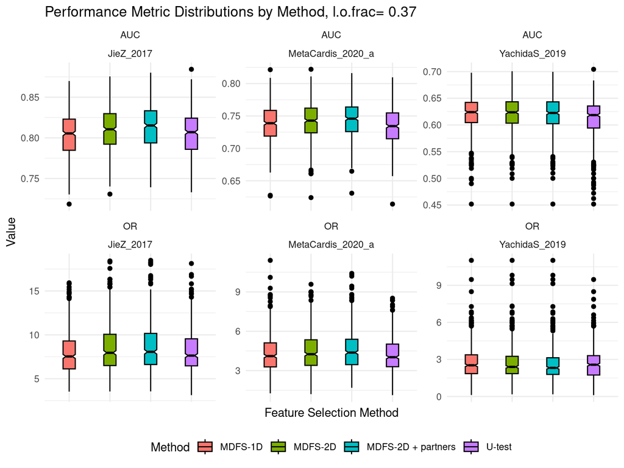

```r
#library(dplyr)
#summary_lines <- long_perf %>%
#  group_by(Metric, Method) %>%
#  summarise(
#    median = median(Value),
#    notch_lower = quantile(Value, 0.25) + 1.57 * IQR(Value) / sqrt(n()),
#    notch_upper = quantile(Value, 0.75) - 1.57 * IQR(Value) / sqrt(n()),
#    .groups = "drop"
#  )


# Violin plot to show distribution
levels(long_perf$Method)<- c("MDFS-1D", "MDFS-2D", "MDFS-2D + partners", "U-test", "md12DpInt")
long_perf<- long_perf[long_perf$Method!="md12DpInt",]
P<-ggplot(long_perf[(!(
                  (long_perf$Metric=="OR") &
                   (long_perf$Value>19)
                    ))
                   , ]

       , aes(x = Method, y = Value, fill = Method)) +
  #geom_violin(trim = FALSE, alpha = 0.7) +
  geom_boxplot(width = 0.3, color = "black", notch = TRUE) +
   #geom_hline(data = summary_lines, aes(yintercept = median, color = Method), linetype = "solid") +

  # Add dashed lines for notches
#  geom_hline(data = summary_lines, aes(yintercept = notch_lower, color = Method), linetype = "dashed") +
 # geom_hline(data = summary_lines, aes(yintercept = notch_upper, color = Method), linetype = "dashed") +
  facet_wrap( Metric~Cohort, scales = "free_y") +  # Separate plots for AUC and OR
  #theme_minimal() +
  labs(title = sprintf("Performance Metric Distributions by Method, l.o.frac= %.2f",lop),
       y = "Value", x = "Feature Selection Method") +theme_minimal()+
  theme(legend.position = "bottom", axis.text.x=element_blank(), axis.ticks.x=element_blank())
print(P)
```

```r
ggsave("figures/perf_additional.pdf", P)
```

```r
universe<- colnames(taxa[[1]])

features_AP_90<- list()
frequent_<- list(over95= .95*n_repeats, over90=.9*n_repeats)

for (coh in cohort_ids){
do.call(rbind,lapply(
features, function(method) Reduce("+", lapply(method[[coh]], function(x) universe %in% x))))->feature_absence_presence

colnames(feature_absence_presence)<-universe

feature_absence_presence[, colAnys(feature_absence_presence >= frequent_$over90), drop=FALSE] -> features_AP_90[[coh]]
}
```

```r
(features_AP_90$JieZ_2017 |> colnames()) %in% Reduce(union,lapply(MDFS_global[[1]], function(x) x$rel_set))
```

```
 [1] TRUE TRUE TRUE TRUE TRUE TRUE TRUE TRUE TRUE TRUE TRUE TRUE TRUE TRUE TRUE
[16] TRUE TRUE TRUE TRUE TRUE TRUE
```

```r
(features_AP_90$MetaCardis_2020_a |> colnames()) %in% Reduce(union,lapply(MDFS_global[[2]], function(x) x$rel_set))
```

```
[1] TRUE TRUE TRUE TRUE TRUE TRUE
```

```r
(features_AP_90$YachidaS_2019 |> colnames()) %in% Reduce(union,lapply(MDFS_global[[3]], function(x) x$rel_set))
```

```
[1] TRUE
```

```r
print(cohort_ids[[1]])
```

```
[1] "JieZ_2017"
```

```r
features_AP_90$JieZ_2017 |> t()
```

```
                              md1D md12D md12Dp   u
Ruminococcus_gnavus            389   393    394 474
Actinomyces_sp_oral_taxon_181  498   498    498 498
Streptococcus_oralis           490   495    495 500
Streptococcus_mitis            500   500    500 500
Atopobium_parvulum             498   498    498 498
Actinomyces_sp_S6_Spd3         500   500    500 500
Streptococcus_parasanguinis    364   372    372 485
Gordonibacter_pamelaeae        256   279    280 453
Gemella_morbillorum            464   465    465 450
Lactobacillus_salivarius       469   469    469 485
Streptococcus_anginosus_group  500   500    500 500
Lactobacillus_mucosae          454   454    454 441
Streptococcus_vestibularis     499   499    499 500
Actinomyces_odontolyticus      500   500    500 500
Tyzzerella_nexilis             369   462    473 332
Streptococcus_sanguinis        310   325    325 481
Mogibacterium_diversum         399   414    414 454
Rothia_mucilaginosa            470   470    470 500
Streptococcus_infantis         497   498    498 500
Actinomyces_sp_HMSC035G02      492   492    492 493
Gemella_haemolysans            456   462    462 464
```

```r
print(cohort_ids[[2]])
```

```
[1] "MetaCardis_2020_a"
```

```r
features_AP_90$MetaCardis_2020_a |> t()
```

```
                             md1D md12D md12Dp   u
Escherichia_coli              499   500    500 500
Firmicutes_bacterium_CAG_110  499   500    500 497
Roseburia_sp_CAG_309          388   400    400 458
Firmicutes_bacterium_CAG_95   478   482    482 495
Clostridium_sp_CAG_167        495   496    496 500
Clostridium_bolteae           447   455    455 475
```

```r
print(cohort_ids[[3]])
```

```
[1] "YachidaS_2019"
```

```r
features_AP_90$YachidaS_2019|> t()
```

```
                    md1D md12D md12Dp   u
Gemella_morbillorum  489   489    489 483
```

```r
print("Fraction of plausible taxa found by U-test in global run, also found in one global run MDFS")
```

```
[1] "Fraction of plausible taxa found by U-test in global run, also found in one global run MDFS"
```

```r
mapply(function(mdfs, u, recurrent90){
  #print(rownames(recurrent90))
  Reduce(union,lapply(mdfs, function(x) union(x$rel_set, x$partner_set) ))-> all_the_mdfs_vars
  u$rel_set-> u_vars
  intersect(all_the_mdfs_vars, colnames(recurrent90))-> all_the_mdfs_vars
  intersect(u_vars, colnames(recurrent90))-> u_vars
 # print(all_the_mdfs_vars)
#  print(u_vars)
  sum(u_vars %in% all_the_mdfs_vars)/length(u_vars)},
  MDFS_global, U_global, features_AP_90

  )
```

```
[1] 1 1 1
```

#### Permutation test

Handled by `permutation_additional.R` script- before subsampling, decision vectors were permuted. Here are the results:

```r
perm_subsample<- readRDS("new_cohorts_subsample_perm.rds")

lop=0.37
set.seed(123)
n_repeats=500

perm_features<- list(md1D=list(),
                md12D=list(),
                md12Dp=list(),
                u=list()
                )
for (fs in names(perm_features))
    for (coh in cohort_ids)
    perm_features[[fs]][[coh]]=list()

        #cohort name    #repeat   #leave out perc.
perm_fs_j_pattern="features/perm_%s_fs_set_j=%d_lop=%.2f.rds"

perm_full_MDFSres<- perm_full_Ures<-list()
for (coh in cohort_ids) perm_full_MDFSres[[coh]]<-perm_full_Ures[[coh]]<-list()

for (j in 1:n_repeats){
for (coh in cohort_ids){

  perm_fs_j_fname= sprintf(perm_fs_j_pattern,coh,j,lop)
  if(!file.exists(perm_fs_j_fname)){
      stop(sprintf("%s should exist!",perm_fs_j_fname))
                } else
                {
    fs_j= readRDS(perm_fs_j_fname)
        all_mdfs_j=fs_j$mdfs
        u_j=fs_j$u
                }
    perm_full_MDFSres[[coh]][[j]]=all_mdfs_j
    perm_full_Ures[[coh]][[j]]=u_j

    perm_features$u[[coh]][[j]]=u_j$rel_set
    perm_features$md1D[[coh]][[j]]=union(all_mdfs_j$res_1Dm$rel_set, all_mdfs_j$res_1D0$rel_set)
        perm_features$md12D[[coh]][[j]]=Reduce(union, list(all_mdfs_j$res_2Dm$rel_set,
                                                  all_mdfs_j$res_2D0$rel_set,
                                                  features$md1D[[coh]][[j]]))
        perm_features$md12Dp[[coh]][[j]]=Reduce(union, list(all_mdfs_j$res_2Dm$partner_set,
                                                       all_mdfs_j$res_2D0$partner_set,
                                                  features$md12D[[coh]][[j]]))


}
if ((j-1)%%50 == 0) message(sprintf( "%d / %d done", j, n_repeats))
}
```

```
1 / 500 done
```

```
51 / 500 done
```

```
101 / 500 done
```

```
151 / 500 done
```

```
201 / 500 done
```

```
251 / 500 done
```

```
301 / 500 done
```

```
351 / 500 done
```

```
401 / 500 done
```

```
451 / 500 done
```

```r
eFPR<-lapply(cohort_ids, function(coh)
         list(md1D0=vector(),
     md1Dm=vector(),
     md2Dm=vector(),
     md2D0=vector(),
     u=vector())
         )
names(eFPR)<-cohort_ids
for (coh in cohort_ids)
for (j in 1:n_repeats){
eFPR[[coh]][['md1D0']][[j]]=length(perm_full_MDFSres[[coh]][[j]]$res_1D0$rel_set)/length(perm_full_MDFSres[[coh]][[j]]$res_1D0$feature_names)
eFPR[[coh]][['md1Dm']][[j]]=length(perm_full_MDFSres[[coh]][[j]]$res_1Dm$rel_set)/length(perm_full_MDFSres[[coh]][[j]]$res_1Dm$feature_names)
eFPR[[coh]][['md2D0']][[j]]=length(perm_full_MDFSres[[coh]][[j]]$res_2D0$rel_set)/length(perm_full_MDFSres[[coh]][[j]]$res_2D0$feature_names)
eFPR[[coh]][['md2Dm']][[j]]=length(perm_full_MDFSres[[coh]][[j]]$res_2Dm$rel_set)/length(perm_full_MDFSres[[coh]][[j]]$res_2Dm$feature_names)
eFPR[[coh]][['u']][[j]]=length(perm_full_Ures[[coh]][[j]]$rel_set)/length(perm_full_MDFSres[[coh]][[j]]$res_1D0$feature_names) #same filtering on sparsity in U_test

}
```

```r
nameMap<- rep(NA, length(eFPR))
nameMap<- as.list(nameMap)
nameMap$md1D0='MDFS1D-zero'
nameMap$md1Dm='MDFS1D-median'
nameMap$md2D0='MDFS2D-zero'
nameMap$md2Dm='MDFS2D-median'
nameMap$u='U-test'
for (coh in cohort_ids)
for (name in names(eFPR[[coh]])){
    cat(sprintf("\n %s: \nsummary for %s method:\n  percentage of selected variables with permuted decision \n  per permutation repeat, highest percentiles", coh,
              nameMap[[name]]))
    cat(paste0("\n    ", capture.output(
                          round(quantile(eFPR[[coh]][[name]], probs=seq(0.93,1,0.02)),4)

                        )
            )
         )
}
```

```
 JieZ_2017:
summary for MDFS1D-zero method:
  percentage of selected variables with permuted decision
  per permutation repeat, highest percentiles
       93%    95%    97%    99%
    0.0000 0.0000 0.0047 0.0049
 JieZ_2017:
summary for MDFS1D-median method:
  percentage of selected variables with permuted decision
  per permutation repeat, highest percentiles
       93%    95%    97%    99%
    0.0000 0.0000 0.0044 0.0045
 JieZ_2017:
summary for MDFS2D-median method:
  percentage of selected variables with permuted decision
  per permutation repeat, highest percentiles
       93%    95%    97%    99%
    0.0000 0.0045 0.0046 0.0089
 JieZ_2017:
summary for MDFS2D-zero method:
  percentage of selected variables with permuted decision
  per permutation repeat, highest percentiles
       93%    95%    97%    99%
    0.0000 0.0047 0.0049 0.0095
 JieZ_2017:
summary for U-test method:
  percentage of selected variables with permuted decision
  per permutation repeat, highest percentiles
       93%    95%    97%    99%
    0.0000 0.0000 0.0001 0.0048
 MetaCardis_2020_a:
summary for MDFS1D-zero method:
  percentage of selected variables with permuted decision
  per permutation repeat, highest percentiles
       93%    95%    97%    99%
    0.0000 0.0000 0.0045 0.0046
 MetaCardis_2020_a:
summary for MDFS1D-median method:
  percentage of selected variables with permuted decision
  per permutation repeat, highest percentiles
```

[output cut: 35 more lines]

```
  per permutation repeat, highest percentiles
       93%    95%    97%    99%
    0.0000 0.0002 0.0043 0.0044
 YachidaS_2019:
summary for MDFS2D-zero method:
  percentage of selected variables with permuted decision
  per permutation repeat, highest percentiles
       93%    95%    97%    99%
    0.0000 0.0000 0.0043 0.0044
 YachidaS_2019:
summary for U-test method:
  percentage of selected variables with permuted decision
  per permutation repeat, highest percentiles
       93%    95%    97%    99%
    0.0000 0.0000 0.0000 0.0043
```

```r
max_permIG<-list()
for (coh in cohort_ids){
max_permIG[[coh]]<- data.frame(IG1D= lapply(perm_full_MDFSres[[coh]], function(x) max(max(x$res_1D0$statistic), max(x$res_1Dm$statistic)))|>unlist(),
                IG2D= lapply(perm_full_MDFSres[[coh]], function(x) max(max(x$res_2D0$statistic), max(x$res_2Dm$statistic)))|>unlist())
}
```

```r
for (coh in cohort_ids)
for (name in names(max_permIG[[coh]])){
    cat(sprintf("\n %s:\n percentiles of maximum %s observed - over permuations",coh, name))
    cat(paste0("\n    ", capture.output(round(quantile(max_permIG[[coh]][[name]], probs=seq(0,1,0.1)),2 ))))
}
```

```
 JieZ_2017:
 percentiles of maximum IG1D observed - over permuations
       0%   10%   20%   30%   40%   50%   60%   70%   80%   90%  100%
     3.05  4.60  5.13  5.58  5.83  6.26  6.68  7.06  7.83  8.89 13.69
 JieZ_2017:
 percentiles of maximum IG2D observed - over permuations
       0%   10%   20%   30%   40%   50%   60%   70%   80%   90%  100%
    11.77 13.21 13.83 14.34 14.74 15.18 15.77 16.34 17.12 18.29 21.94
 MetaCardis_2020_a:
 percentiles of maximum IG1D observed - over permuations
       0%   10%   20%   30%   40%   50%   60%   70%   80%   90%  100%
     3.24  4.75  5.20  5.52  6.03  6.32  6.72  7.31  7.98  8.86 14.27
 MetaCardis_2020_a:
 percentiles of maximum IG2D observed - over permuations
       0%   10%   20%   30%   40%   50%   60%   70%   80%   90%  100%
    11.19 12.79 13.29 13.76 14.22 14.52 14.99 15.55 16.21 17.16 21.11
 YachidaS_2019:
 percentiles of maximum IG1D observed - over permuations
       0%   10%   20%   30%   40%   50%   60%   70%   80%   90%  100%
     3.30  4.59  5.13  5.49  6.04  6.36  6.66  7.21  7.92  8.83 13.01
 YachidaS_2019:
 percentiles of maximum IG2D observed - over permuations
       0%   10%   20%   30%   40%   50%   60%   70%   80%   90%  100%
    11.26 13.23 13.99 14.46 14.82 15.19 15.60 16.16 16.75 17.72 22.63
```